# IF540_Kelas EL_00000054804_Christopher Darren_Week08

## TUGAS LAB IF540 MACHINE LEARNING

### WEEK 08 : Pembelajaran Mendalam

#### Semester Genap 2022/2023

```python
# Run this code when you restart the machine
# Fill in with YOUR name and NIM
import datetime
import uuid

myName = "Christopher Darren"
myNIM = "00000054804"
```

```python
myDate = datetime.datetime.now()
myDevice = str(uuid.uuid1())

print("Name: \t\t{}".format(myName))
print("NIM: \t\t{}".format(myNIM))
print("Start: \t\t{}".format(myDate))
print("Device ID: \t{}".format(myDevice))
```

```
Name: 		Christopher Darren
NIM: 		00000054804
Start: 		2023-04-13 09:14:43.885427
Device ID: 	f4874687-d9a0-11ed-a053-f02f74a116e8
```

### Dataset yang dipakai:

1. KMNIST – sumber : https://www.kaggle.com/datasets/sivakrishnathota/sivakmnist?select=kmnist-train-labels.npz

### Hasil kerja

##### Lets install Jupyter, which the editor we will use in this course :

```python
#conda install -y jupyter
```

#### We will actually lunch Jupyter later.

```python
#conda env create -f tensorflow.yml -n tensorflow_env
```

```python
#conda activate tensorflow_env
```

```python
conda info --envs
```

```
# conda environments:
#
base                     C:\Users\Darren\anaconda3
tensorflow_env           C:\Users\Darren\anaconda3\envs\tensorflow_env
tensorflowml          *  C:\Users\Darren\anaconda3\envs\tensorflowml
```

#### Run your Jupyter notebook and check the versions expected.

```python
import sys

import tensorflow.keras
import pandas as pd
import sklearn as sk
import tensorflow as tf
```

#### From the code, we get print the output with this following code

```python
print(f"Tensor Flow Version: {tf.__version__}")
print(f"Keras Version: {tensorflow.keras.__version__}")
print()
print(f"Python {sys.version}")
print(f"Pandas {pd.__version__}")
print(f"Scikit-Learn {sk.__version__}")
```

```
Tensor Flow Version: 2.4.0
Keras Version: 2.4.0

Python 3.8.16 (default, Mar  2 2023, 03:18:16) [MSC v.1916 64 bit (AMD64)]
Pandas 1.5.3
Scikit-Learn 1.2.2
```

### Convolutional Neural Networks (CNN)

#### CNN is a neural network technology that has profoundly impacted the area of computer vision (CV). This advantage in CNN is due to years of research on biological eyes. In other words, CNN utilize overlapping fields of input to simulate features of biological eyes. Until this breakthrough, AI had been unable to reproduce the capabilities of biological vision.

#### There are many datasets for computer vision. Two of the most popular are the MNIST digits dataset and the CIFAR image datasets.

### MNIST Digits dataset

#### 1. Import the libraries

```python
import tensorflow.keras
from tensorflow.keras.callbacks import EarlyStopping
from tensorflow.keras.layers import Dense, Dropout
from tensorflow.keras import regularizers
from tensorflow.keras.datasets import mnist

(x_train, y_train), (x_test, y_test) = mnist.load_data()
print("Shape of x_train: {}".format(x_train.shape))
print("Shape of y_train: {}".format(y_train.shape))
print()
print("Shape of x_test: {}".format(x_test.shape))
print("Shape of y_test: {}".format(y_test.shape))
```

```
Shape of x_train: (60000, 28, 28)
Shape of y_train: (60000,)

Shape of x_test: (10000, 28, 28)
Shape of y_test: (10000,)
```

#### 2 Display the Digits

```python
from IPython.display import display
import pandas as pd

# Display as text
pd.set_option('display.max_columns', 15)
pd.set_option('display.max_rows', 5)

print("Shape for dataset: {}".format(x_train.shape))
print("Labels: {}".format(y_train))

# Single MNIST digit
single = x_train[0]
print("Shape for single: {}".format(single.shape))

pd.DataFrame(single.reshape(28,28))
```

```
Shape for dataset: (60000, 28, 28)
Labels: [5 0 4 ... 5 6 8]
Shape for single: (28, 28)
```

|  | 0 | 1 | 2 | 3 | 4 | 5 | 6 | ... | 21 | 22 | 23 | 24 | 25 | 26 | 27 |
| --- | --- | --- | --- | --- | --- | --- | --- | --- | --- | --- | --- | --- | --- | --- | --- |
| 0 | 0 | 0 | 0 | 0 | 0 | 0 | 0 | ... | 0 | 0 | 0 | 0 | 0 | 0 | 0 |
| 1 | 0 | 0 | 0 | 0 | 0 | 0 | 0 | ... | 0 | 0 | 0 | 0 | 0 | 0 | 0 |
| ... | ... | ... | ... | ... | ... | ... | ... | ... | ... | ... | ... | ... | ... | ... | ... |
| 26 | 0 | 0 | 0 | 0 | 0 | 0 | 0 | ... | 0 | 0 | 0 | 0 | 0 | 0 | 0 |
| 27 | 0 | 0 | 0 | 0 | 0 | 0 | 0 | ... | 0 | 0 | 0 | 0 | 0 | 0 | 0 |

28 rows × 28 columns

#### 3. Lets display as image

```
Image (#105): Which is digit '1'
```

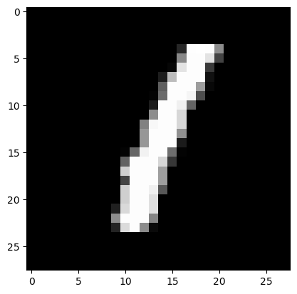

```python
# Display as image
import matplotlib.pyplot as plt
import numpy as np
digit = 105 # Change to choose new digit
a= x_train[digit]
plt.imshow(a, cmap='gray', interpolation='nearest')
print("Image (#{}): Which is digit '{}'".format(digit, y_train[digit]))
```

#### 4. We can show the dataset with random. Using random library to show the figure

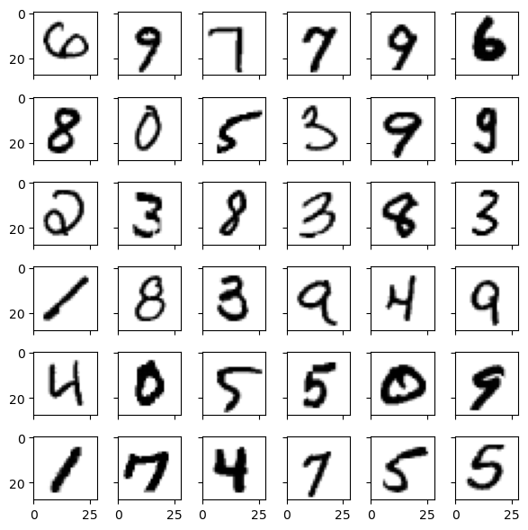

```python
import random

ROWS = 6
random_indices = random.sample(range(x_train.shape[0]), ROWS*ROWS)

sample_images = x_train[random_indices, :]

plt.clf()

fig, axes = plt.subplots(ROWS, ROWS,
                        figsize=(ROWS, ROWS),
                        sharex=True, sharey=True)

for i in range (ROWS*ROWS):
    subplot_row = i//ROWS
    subplot_col = i%ROWS
    ax = axes[subplot_row, subplot_col]

    plottable_image = np.reshape(sample_images[i, :], (28,28))
    ax.imshow(plottable_image, cmap='gray_r')

    ax.set_xbound([0,28])

plt.tight_layout()
plt.show()
```

#### 5. Split the data and input the parameter of CNN algorithm before make a model (train the data)

```python
import tensorflow.keras
from tensorflow.keras.datasets import mnist
from tensorflow.keras.models import Sequential
from tensorflow.keras.layers import Dense, Dropout, Flatten
from tensorflow.keras.layers import Conv2D, MaxPooling2D
from tensorflow.keras import backend as K
batch_size = 128
num_classes = 10
epochs = 12

img_rows, img_cols = 28, 28
if K.image_data_format() == 'channels_first':
    x_train = x_train.reshape(x_train.shape[0], 1, img_rows, img_cols)
    x_test = x_test.reshape(x_test.shape[0], 1, img_rows, img_cols)
    input_shape = (5, img_rows, img_cols)
else:
    x_train = x_train.reshape(x_train.shape[0], img_rows, img_cols, 1)
    x_test = x_test.reshape(x_test.shape[0], img_rows, img_cols, 1)
    input_shape = (5, img_rows, img_cols, 1)
x_train = x_train.astype('float32')
x_test = x_test.astype('float32')

x_train /= 255
x_test /= 255
print('x_train shape:', x_train.shape)
print("Training samples: {}".format(x_train.shape[0]))
print("Test samples: {}".format(x_test.shape[0]))

y_train = tensorflow.keras.utils.to_categorical(y_train, num_classes)
y_test = tensorflow.keras.utils.to_categorical(y_test, num_classes)
model = Sequential()
model.add(Conv2D(32, kernel_size=(3, 3),
                activation='relu',
                input_shape=input_shape))
model.add(Conv2D(64, (3, 3), activation='relu'))
#model.add(MaxPooling2D(pool_size=(2, 2)))
model.add(Dropout(0.25))
model.add(Flatten())
model.add(Dense(128, activation='relu'))
model.add(Dropout(0.5))
model.add(Dense(num_classes, activation='softmax'))
model.compile(loss='categorical_crossentropy', optimizer='adam',metrics=['accuracy'])
```

```
x_train shape: (60000, 28, 28, 1)
Training samples: 60000
Test samples: 10000
```

```python
model.summary()
```

```
Model: "sequential_33"
_________________________________________________________________
Layer (type)                 Output Shape              Param #
=================================================================
conv2d_66 (Conv2D)           (None, 5, 26, 26, 32)     320
_________________________________________________________________
conv2d_67 (Conv2D)           (None, 5, 24, 24, 64)     18496
_________________________________________________________________
dropout_44 (Dropout)         (None, 5, 24, 24, 64)     0
_________________________________________________________________
flatten_24 (Flatten)         (None, 184320)            0
_________________________________________________________________
dense_48 (Dense)             (None, 128)               23593088
_________________________________________________________________
dropout_45 (Dropout)         (None, 128)               0
_________________________________________________________________
dense_49 (Dense)             (None, 10)                1290
=================================================================
Total params: 23,613,194
Trainable params: 23,613,194
Non-trainable params: 0
_________________________________________________________________
```

#### 6. Training the CNN – DIGITS datasets. This can take awhile

```python
x_train = x_train.reshape(x_train.shape[0], 1, 28, 28, 1)
x_test = x_test.reshape(x_test.shape[0], 1, 28, 28, 1)
model.compile(optimizer='adam', loss='categorical_crossentropy')
```

```python
import tensorflow as tf
import time

start_time = time.time()

model.fit(x_train, y_train,batch_size=batch_size,epochs=epochs,verbose=3,validation_data=(x_test, y_test))
score = model.evaluate(x_test, y_test, verbose=0)
print('Test loss: {}'.format(score[0]))
print('Test accuracy: {}'.format(score[1]))


def hms_string(sec):
    hours = int(sec / 3600)
    minutes = int((sec % 3600) / 60)
    seconds = int(sec % 60)
    return "{:02d}:{:02d}:{:02d}".format(hours, minutes, seconds)

elapsed_time = time.time() - start_time
print("Elapsed time: {}".format(hms_string(elapsed_time)))
```

[output not shown]

[output not shown]

[output cut: 84 more lines]

[output not shown]

#### saya sekip modul tutorial karena error

#### Importing numpy library

```python
import numpy as np
```

## ---DATASET SENDIRI---

#### importing dataset

```python
# Load the data from the .npz file
x_train = np.load('D:\SEMESTER 4\IF540 Machine Learning\LAB\week8\kmnist-train-imgs.npz')['arr_0']
y_train = np.load('D:\SEMESTER 4\IF540 Machine Learning\LAB\week8\kmnist-train-labels.npz')['arr_0'].reshape(-1, 1)
x_test =  np.load('D:\SEMESTER 4\IF540 Machine Learning\LAB\week8\kmnist-test-imgs.npz')['arr_0']
y_test =  np.load('D:\SEMESTER 4\IF540 Machine Learning\LAB\week8\kmnist-test-labels.npz')['arr_0'].reshape(-1, 1)

print("Shape of x_train: ", x_train.shape)
print("Shape of y_train: ",y_train.shape)
print()
print("Shape of x_test: ", x_test.shape)
print("Shape of y_test: ",y_test.shape)
```

```
Shape of x_train:  (60000, 28, 28)
Shape of y_train:  (60000, 1)

Shape of x_test:  (10000, 28, 28)
Shape of y_test:  (10000, 1)
```

#### 2 Display the Kmnist dataset

```python
from IPython.display import display
import pandas as pd

# Display as text
pd.set_option('display.max_columns', 15)
pd.set_option('display.max_rows', 5)

print("Shape for dataset: {}".format(x_train.shape))
print("Labels: {}".format(y_train))

# Single MNIST digit
single = x_train[0]
print("Shape for single: {}".format(single.shape))

pd.DataFrame(single.reshape(28,28))
```

```
Shape for dataset: (60000, 28, 28)
Labels: [[8]
 [7]
 [0]
 ...
 [0]
 [4]
 [9]]
Shape for single: (28, 28)
```

|  | 0 | 1 | 2 | 3 | 4 | 5 | 6 | ... | 21 | 22 | 23 | 24 | 25 | 26 | 27 |
| --- | --- | --- | --- | --- | --- | --- | --- | --- | --- | --- | --- | --- | --- | --- | --- |
| 0 | 0 | 0 | 0 | 0 | 0 | 0 | 0 | ... | 0 | 0 | 0 | 0 | 0 | 0 | 0 |
| 1 | 0 | 0 | 0 | 0 | 0 | 0 | 0 | ... | 0 | 0 | 0 | 0 | 0 | 0 | 0 |
| ... | ... | ... | ... | ... | ... | ... | ... | ... | ... | ... | ... | ... | ... | ... | ... |
| 26 | 0 | 0 | 0 | 0 | 0 | 0 | 0 | ... | 0 | 0 | 0 | 0 | 0 | 0 | 0 |
| 27 | 0 | 0 | 0 | 0 | 0 | 0 | 0 | ... | 0 | 0 | 0 | 0 | 0 | 0 | 0 |

28 rows × 28 columns

#### 3. Lets display as image

```
Image (#285): Which is digit '[5]'
```

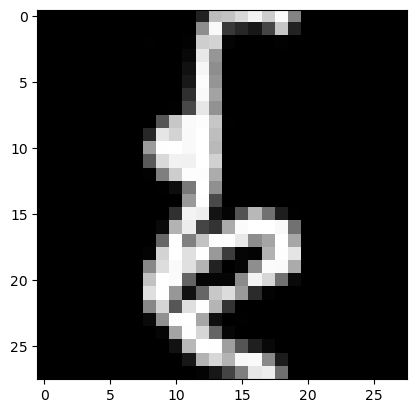

```python
# Display as image
import matplotlib.pyplot as plt
import numpy as np
digit = 285 # Change to choose new digit
a= x_train[digit]
plt.imshow(a, cmap='gray', interpolation='nearest')
print("Image (#{}): Which is digit '{}'".format(digit, y_train[digit]))
```

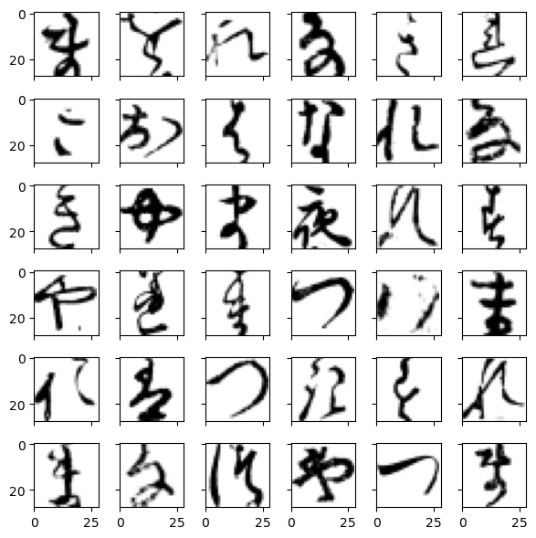

```python
import random

ROWS = 6
random_indices = random.sample(range(x_train.shape[0]), ROWS*ROWS)

sample_images = x_train[random_indices, :]

plt.clf()

fig, axes = plt.subplots(ROWS, ROWS,
                        figsize=(ROWS, ROWS),
                        sharex=True, sharey=True)

for i in range (ROWS*ROWS):
    subplot_row = i//ROWS
    subplot_col = i%ROWS
    ax = axes[subplot_row, subplot_col]

    plottable_image = np.reshape(sample_images[i, :], (28,28))
    ax.imshow(plottable_image, cmap='gray_r')

    ax.set_xbound([0,28])

plt.tight_layout()
plt.show()
```

### 5. Split the data and input the parameter of CNN algorithm before make a model (train the data)

```python
import tensorflow.keras
from tensorflow.keras.datasets import mnist
from tensorflow.keras.models import Sequential
from tensorflow.keras.layers import Dense, Dropout, Flatten
from tensorflow.keras.layers import Conv2D, MaxPooling2D
from tensorflow.keras import backend as K

batch_size = 256
num_classes = len(np.unique(y_train))
epochs = 12

img_rows, img_cols = 28, 28
if K.image_data_format() == 'channels_first':
    x_train = x_train.reshape(x_train.shape[0], 1, img_rows, img_cols)
    x_test = x_test.reshape(x_test.shape[0], 1, img_rows, img_cols)
    input_shape = (5, img_rows, img_cols)
else:
    x_train = x_train.reshape(x_train.shape[0], img_rows, img_cols, 1)
    x_test = x_test.reshape(x_test.shape[0], img_rows, img_cols, 1)
    input_shape = (5, img_rows, img_cols, 1)
x_train = x_train.astype('float32')
x_test = x_test.astype('float32')

x_train /= 255
x_test /= 255
print('x_train shape:', x_train.shape)
print("Training samples: {}".format(x_train.shape[0]))
print("Test samples: {}".format(x_test.shape[0]))

y_train = tensorflow.keras.utils.to_categorical(y_train, num_classes)
y_test = tensorflow.keras.utils.to_categorical(y_test, num_classes)

# Define the model architecture
model = Sequential()
model.add(Conv2D(32, kernel_size=(3, 3), activation='relu', input_shape=(28, 28, 1)))
model.add(Conv2D(64, (3, 3), activation='relu'))
model.add(MaxPooling2D(pool_size=(2, 2)))
model.add(Dropout(0.25))
model.add(Flatten())
model.add(Dense(128, activation='relu'))
model.add(Dropout(0.5))
model.add(Dense(num_classes, activation='softmax'))

model.compile(loss='categorical_crossentropy', optimizer='adam',metrics=['accuracy'])
```

```
x_train shape: (60000, 28, 28, 1)
Training samples: 60000
Test samples: 10000
```

```python
model.summary()
```

```
Model: "sequential_32"
_________________________________________________________________
Layer (type)                 Output Shape              Param #
=================================================================
conv2d_64 (Conv2D)           (None, 26, 26, 32)        320
_________________________________________________________________
conv2d_65 (Conv2D)           (None, 24, 24, 64)        18496
_________________________________________________________________
max_pooling2d_29 (MaxPooling (None, 12, 12, 64)        0
_________________________________________________________________
dropout_42 (Dropout)         (None, 12, 12, 64)        0
_________________________________________________________________
flatten_23 (Flatten)         (None, 9216)              0
_________________________________________________________________
dense_46 (Dense)             (None, 128)               1179776
_________________________________________________________________
dropout_43 (Dropout)         (None, 128)               0
_________________________________________________________________
dense_47 (Dense)             (None, 10)                1290
=================================================================
Total params: 1,199,882
Trainable params: 1,199,882
Non-trainable params: 0
_________________________________________________________________
```

#### 6.Training the CNN – KMNITS datasets. This can take awhile

```python
import tensorflow as tf
import time

start_time = time.time()

model.fit(x_train, y_train,batch_size=batch_size,epochs=epochs,verbose=3,validation_data=(x_test, y_test))
score = model.evaluate(x_test, y_test, verbose=0)
print('Test loss: {}'.format(score[0]))
print('Test accuracy: {}'.format(score[1]))


def hms_string(sec):
    hours = int(sec / 3600)
    minutes = int((sec % 3600) / 60)
    seconds = int(sec % 60)
    return "{:02d}:{:02d}:{:02d}".format(hours, minutes, seconds)

elapsed_time = time.time() - start_time
print("Elapsed time: {}".format(hms_string(elapsed_time)))
```

```
Test loss: 0.2055513709783554
Test accuracy: 0.9513000249862671
Elapsed time: 00:07:19
```

#### 7. Evaluate accuracy from KMNITS dataset

```python
# set the desired Tensorflow output level
score = model.evaluate(x_test, y_test, verbose=0)
print('Test loss: {}'.format(score[0]))
print('Test accuracy: {}'.format(score[1]))
```

```
Test loss: 0.2055513709783554
Test accuracy: 0.9513000249862671
```

```python
from sklearn import metrics

small_x = x_test[1:100]
small_y = y_test[1:100]
small_y2 = np.argmax(small_y,axis=1)
pred = model.predict(small_x)
pred = np.argmax(pred,axis=1)
score = metrics.accuracy_score(small_y2, pred)
print('Accuracy: {}'.format(score))
```

```
Accuracy: 0.9494949494949495
```

### Kesimpulan

Berikan simpulan yang dilakukan dari hasil kerja menggunakan algoritma dan 2 dataset yang dipilih. Simpulan bisa berkisar antara (bisa di modifikasi):

[output not shown]

```python
# Footer
myDate = datetime.datetime.now()
print("I certify that this is my own work.")
print("Signed by:")
print("Name: \t\t{}".format(myName))
print("NIM: \t\t{}".format(myNIM))
print("Time-stamp:\t{}".format(myDate))
```

```
I certify that this is my own work.
Signed by:
Name: 		Christopher Darren
NIM: 		00000054804
Time-stamp:	2023-04-19 21:23:11.614866
```

### Save the notebook, then convert the notebook to html (by running the next code).

```python
!jupyter nbconvert --to html "./IF540_Kelas EL_00000054804_Christopher Darren_Week08.ipynb" --output-dir="./"
```